# Additional Coding: Update #5

davegoblue

October 18, 2016

## Overview

This document explores video poker hands, using http://wizardofodds.com/games/video-poker/methodology/ as a template, and applying DataCamp_Insights_v001 materials where applicable. This document builds on the more salient components of the analysis in AdditionalCoding_v004.Rmd.

## Analysis Approach

The Wizard of Odds suggests an 11-step approach to calculating the returns for a video poker pay table:

1. Initialize arrays for discarding 0-5 cards
2. Loop through all 52c5 hands, score them based on their poker value, then place them in the appropriate arrays (each of discard 0 through discard 5)
3. Create the 134,459 non-duplicate starting hands possible (e.g., Ad Kh Tc 9c 3d is the same as As Kh Td 9d 3s), and assign it a weighting based on how much duplication it covers
4. Lookup each of the 134,459 hands and score the discard 0 (hold 5) option
5. Lookup every possible discard 1 (hold 4) option, find the EV in the discard 1 array and then subtract the outcome in the discard 0 array (cannot get back the same hand)
6. Lookup every possible discard 2 (hold 3) option, find the EV in the discard 2 array and then subtract the outcomes in the discard 1 array and then add back the outcome in the discard 0 array (double-subtracted)
7. Lookup every possible discard 3 (hold 2) option, find the EV in the discard 3 array and then subtract the outcomes in the discard 2 array and then add back the outcomes in the discard 1 array and then subtract out the outcome in the discard 0 array (typical set theory add/subtract)
8. Lookup every possible discard 4 (hold 1) option, find the EV in the discard 4 array and then subtract the outcomes in the discard 3 array and then add back the outcomes in the discard 2 array and then subtract out the outcome in the discard 1 array and then add back the outcome in the discard 0 array (typical set theory add/subtract)
9. Lookup every possible discard 5 (hold 0) option, find the EV in the discard 5 array and then subtract the outcomes in the discard 4 array and then add back the outcomes in the discard 3 array and then subtract out the outcome in the discard 2 array and then add back the outcome in the discard 1 array and then subtract out the outcome of the discard 0 array (typical set theory add/subtract)
10. Calculate the EV of every possible decision, and assign the appropriate weightings
11. Determine overall return, or other statistics of interest about the game

Steps 2 and 3 are surprisingly time-consuming, and this analysis will look to cache a number of key outcomes for application of a scoring vector at a later stage.

### Step 1: Initialize Arrays

First, the relevant arrays for discard 0 (array0) through discard 5 (array5) are created. A baseline assumption is made that while there are up to 50 types of interesting hands, there are only 16 possible scores driven by these hands. Arrays for storing these are declared for the game of interest:

```r
library(tidyr)
library(dplyr)
```

```r
library(ggplot2)


startTime <- proc.time()


# Declare overall game variables
nHandTypes <- 50  # Number of hand types supported
nScores <- 16  # Number of final scores supported - many hand types may map to the same score



proc.time() - startTime
```

```
##    user  system elapsed
##       0       0       0
```

### Step 2: Create/Score Hands, Create Indexing, and Place Scores in Appropriate Arrays

#### Step 2a: Create/Score Hands

First, the 52c5 possible hands are created, with hand types declared. Of particular interest will be tracking the following:

- Nothing (0)
- Royal Flush (1)
- Straight Flush (2)
- Full House (3)
- Flush (4)
- Straight (5)
- Trips (6)
- Two Pair (7)
- Pair AA (8)
- Pair KK (9)
- Pair QQ (10)
- Pair JJ (11)
- Pair TT (12)
- Pair 22-99 (13)
- AAAA with 2-4 (14)
- AAAA with J-K (15)
- AAAA with 5-T (16)
- 2222/3333/4444 with A (17)
- 2222/3333/4444 with 2-4 (18)
- 2222/3333/4444 with J-K (19)
- 2222/3333/4444 with 5-T (20)
- JJJJ/QQQQ/KKKK with A (21)
- JJJJ/QQQQ/KKKK with 2-4 (22)
- JJJJ/QQQQ/KKKK with J-K (23)
- JJJJ/QQQQ/KKKK with 5-T (24)
- 5555-TTTT (25)

```r
startTime <- proc.time()


# Create the 52c5 hands
aHands <- t(combn(1:52, 5))
str(aHands)
```

```
##  int [1:2598960, 1:5] 1 1 1 1 1 1 1 1 1 1 ...
```

```r
proc.time() - startTime
```

```
##    user  system elapsed
##    2.51    0.02    2.54
```

```r
# Find the ranks and suits
aRanks <- 1 + (aHands-1) %% 13
aSuits <- (aHands-1) %/% 13


# Find the flushes
aFlush <- aSuits[, 1] == aSuits[, 5]


# Find the straights
strMatrix <- matrix(data=0L, nrow=13, ncol=10)
strMatrix[c(1, 10, 11, 12, 13), 1] <- 1L
for (intCtr in 1:9) { strMatrix[intCtr:(intCtr+4), intCtr+1] <- 1L }

aRankCount <- matrix(data=-1L, nrow=choose(52, 5), ncol=13)
for (intCtr in 1:13) { aRankCount[, intCtr] <- rowSums(aRanks == intCtr) }


# Find max and count of ranks (sufficient to determine quads, full houses, trips, two pair, and pair)
aQuads <- rowSums(aRankCount == 4)
aTrips <- rowSums(aRankCount == 3)
aPairs <- rowSums(aRankCount == 2)
aStraight <- rowSums( ((aRankCount == 1) %*% strMatrix) == 5)


# Default is that a hand has nothing
aType <- rep(0L, choose(52, 5))


# Declare types for mainline (RF, SF, FH, FL, ST, 3K, 2P)
aType[aFlush == 1 & aStraight == 1 & aRankCount[, 1] == 1 &
          aRankCount[, 13] == 1] <- 1  # Royal Flush
aType[aFlush == 1 & aStraight == 1 &
          (aRankCount[, 1] == 0 | aRankCount[, 13] == 0)] <- 2  # Straight Flush
aType[aTrips == 1 & aPairs == 1] <- 3  # Full House
aType[aFlush == 1 & aStraight == 0] <- 4  # Flush
aType[aFlush == 0 & aStraight == 1] <- 5  # Straight
aType[aTrips == 1 & aPairs == 0] <- 6  # Trips
aType[aPairs == 2] <- 7  # Two Pair


# Declare types for pairs
aType[aTrips == 0 & aPairs == 1 & aRankCount[, 1] == 2] <- 8  # Pair Aces
aType[aTrips == 0 & aPairs == 1 & aRankCount[, 13] == 2] <- 9  # Pair Kings
aType[aTrips == 0 & aPairs == 1 & aRankCount[, 12] == 2] <- 10  # Pair Queens
aType[aTrips == 0 & aPairs == 1 & aRankCount[, 11] == 2] <- 11  # Pair Jacks
aType[aTrips == 0 & aPairs == 1 & aRankCount[, 10] == 2] <- 12  # Pair Tens
aType[aTrips == 0 & aPairs == 1 & !(aType %in% c(8, 9, 10, 11, 12))] <- 13  # Pair 22-99


# Declare types for quads
quadSubset <- aRankCount[aQuads == 1, ]
quadType <- apply(quadSubset, 1, FUN=function(x) { c(which(x == 4), which(x == 1)) } )
quadScore <- rep(-1L, ncol(quadType))

quadScore[quadType[1, ] == 1 & quadType[2, ] %in% c(2, 3, 4)] <- 14  ## AAAA with 2-4
quadScore[quadType[1, ] == 1 & quadType[2, ] %in% c(11, 12, 13)] <- 15  ## AAAA with J-K
quadScore[quadType[1, ] == 1 & quadType[2, ] %in% c(5, 6, 7, 8, 9, 10)] <- 16  ## AAAA with 5-T

quadScore[quadType[1, ] %in% c(2, 3, 4) &
              quadType[2, ] %in% c(1)] <- 17  ## 2222/3333/4444 with A
quadScore[quadType[1, ] %in% c(2, 3, 4) &
              quadType[2, ] %in% c(2, 3, 4)] <- 18  ## 2222/3333/4444 with 2-4
quadScore[quadType[1, ] %in% c(2, 3, 4) &
              quadType[2, ] %in% c(11, 12, 13)] <- 19  ## 2222/3333/4444 with J-K
quadScore[quadType[1, ] %in% c(2, 3, 4) &
              quadType[2, ] %in% c(5, 6, 7, 8, 9, 10)] <- 20  ## 2222/3333/4444 with 5-T

quadScore[quadType[1, ] %in% c(11, 12, 13) &
              quadType[2, ] %in% c(1)] <- 21  ## JJJJ/QQQQ/KKKK with A
quadScore[quadType[1, ] %in% c(11, 12, 13) &
              quadType[2, ] %in% c(2, 3, 4)] <- 22  ## JJJJ/QQQQ/KKKK with 2-4
quadScore[quadType[1, ] %in% c(11, 12, 13) &
              quadType[2, ] %in% c(11, 12, 13)] <- 23  ## JJJJ/QQQQ/KKKK with J-K
quadScore[quadType[1, ] %in% c(11, 12, 13) &
              quadType[2, ] %in% c(5, 6, 7, 8, 9, 10)] <- 24  ## JJJJ/QQQQ/KKKK with 5-T

quadScore[quadType[1, ] %in% c(5, 6, 7, 8, 9, 10)] <- 25  ## 5555/6666/7777/8888/9999/TTTT with any


# Populate quad results in to aType
aType[aQuads == 1] <- quadScore
data.frame(type=aType) %>% group_by(type) %>% summarize(ct=n()) %>% print.data.frame()
```

```
##    type      ct
## 1     0 1302540
## 2     1       4
## 3     2      36
## 4     3    3744
## 5     4    5108
## 6     5   10200
## 7     6   54912
## 8     7  123552
## 9     8   84480
## 10    9   84480
## 11   10   84480
## 12   11   84480
## 13   12   84480
## 14   13  675840
## 15   14      12
## 16   15      12
## 17   16      24
## 18   17      12
## 19   18      24
## 20   19      36
## 21   20      72
## 22   21      12
## 23   22      36
## 24   23      24
## 25   24      72
## 26   25     288
```

```r
proc.time() - startTime
```

```
##    user  system elapsed
##   10.03    1.16   11.33
```

The process takes ~10 seconds, but with the many interim files, it also consumes ~1.0 GB.

#### Step 2b: Create Indexing

Next, a methodology is created to index any combination of held cards:

```r
startTime <- proc.time()


# Create a matrix to hold results for choose(n, k)
mtxCombin <- matrix(data=0L, nrow=52, ncol=5)
for (intCtr in 1:52) {
    for (intCtr2 in 1:5) {
        # Note that choose() is a guarded function where choose(n, k) returns 0 for k > n
        mtxCombin[intCtr, intCtr2] <- as.integer(choose(intCtr, intCtr2))
    }
}


idxCard1 <- function(c1) {
    # Just return yourself
    c1
}

idxCard2 <- function(c1, c2) {
    # Need to convert the C++ algorithm which is 0:51 to R which wants 1:52
    as.integer(  1 + mtxCombin[52, 2] - mtxCombin[53-c1, 2] +
                     mtxCombin[52-c1, 1] - mtxCombin[53-c2, 1]
              )
}

idxCard3 <- function(c1, c2, c3) {
    # Need to convert the C++ algorithm which is 0:51 to R which wants 1:52
    as.integer(
        1 + mtxCombin[52, 3] - mtxCombin[53-c1, 3] +
            mtxCombin[52-c1, 2] - mtxCombin[53-c2, 2] +
            mtxCombin[52-c2, 1] - mtxCombin[53-c3, 1]
              )
}

idxCard4 <- function(c1, c2, c3, c4) {
    # Need to convert the C++ algorithm which is 0:51 to R which wants 1:52
    as.integer(
        1 + mtxCombin[52, 4] - mtxCombin[53-c1, 4] +
            mtxCombin[52-c1, 3] - mtxCombin[53-c2, 3] +
            mtxCombin[52-c2, 2] - mtxCombin[53-c3, 2] +
            mtxCombin[52-c3, 1] - mtxCombin[53-c4, 1]
              )
}

idxCard5 <- function(c1, c2, c3, c4, c5) {
    # Need to convert the C++ algorithm which is 0:51 to R which wants 1:52
    as.integer(
        1 + mtxCombin[52, 5] - mtxCombin[53-c1, 5] +
            mtxCombin[52-c1, 4] - mtxCombin[53-c2, 4] +
            mtxCombin[52-c2, 3] - mtxCombin[53-c3, 3] +
            mtxCombin[52-c3, 2] - mtxCombin[53-c4, 2] +
            mtxCombin[52-c4, 1] - mtxCombin[53-c5, 1]
             )
}

proc.time() - startTime
```

```
##    user  system elapsed
##       0       0       0
```

This allows any combination of 1-5 cards to be converted to a relevant index. This will be useful for several further components of the program.

#### Step 2c: Place Scores in Appropriate Arrays

Next, each starting hand is assigned indices for keep0/discard5 (which will fill array5) down to keep5/discard0 (which will fill array0). Note that hand types have not yet been converted to scores; this is simply the step for finding the relevant indices:

```r
startTime <- proc.time()


getIndices <- function(nKeep, keyFun) {

    mtxKeep <- combn(1:5, nKeep)
    retResults <- matrix(data=-1L, nrow=nrow(aHands), ncol=ncol(mtxKeep))

    for (intCtr in 1:ncol(mtxKeep)) {
        thisKey <- mtxKeep[, intCtr, drop=TRUE]
        thisList <- lapply(seq_along(thisKey), FUN=function(x) { aHands[, thisKey[x]] } )
        if (length(thisList) == 5) {
            retResults[, intCtr] <- keyFun(thisList[[1]], thisList[[2]], thisList[[3]],
                                           thisList[[4]], thisList[[5]]
                                           )
        } else if (length(thisList) == 4) {
            retResults[, intCtr] <- keyFun(thisList[[1]], thisList[[2]],
                                           thisList[[3]], thisList[[4]]
                                           )
        } else if (length(thisList) == 3) {
            retResults[, intCtr] <- keyFun(thisList[[1]], thisList[[2]], thisList[[3]])
        } else if (length(thisList) == 2) {
            retResults[, intCtr] <- keyFun(thisList[[1]], thisList[[2]])
        } else if (length(thisList) == 1) {
            retResults[, intCtr] <- keyFun(thisList[[1]])
        } else { stop(paste0("Incorrect list length: ", length(thisList))) }
    }

    # Pass back the outcome
    retResults

}


mtxIndices <- matrix(data=-1L, nrow=nrow(aHands), ncol=32)

# Populate the keep-all
mtxIndices[, 1] <- getIndices(nKeep=5, keyFun=idxCard5)
proc.time() - startTime
```

```
##    user  system elapsed
##    1.36    0.31    1.67
```

```r
# Populate the keep-four
mtxIndices[, 2:6] <- getIndices(nKeep=4, keyFun=idxCard4)
proc.time() - startTime
```

```
##    user  system elapsed
##    3.78    0.95    4.75
```

```r
# Populate the keep-three
mtxIndices[, 7:16] <- getIndices(nKeep=3, keyFun=idxCard3)
proc.time() - startTime
```

```
##    user  system elapsed
##    7.71    1.66    9.49
```

```r
# Populate the keep-two
mtxIndices[, 17:26] <- getIndices(nKeep=2, keyFun=idxCard2)
proc.time() - startTime
```

```
##    user  system elapsed
##   10.59    2.09   12.94
```

```r
# Populate the keep-one
mtxIndices[, 27:31] <- getIndices(nKeep=1, keyFun=idxCard1)
proc.time() - startTime
```

```
##    user  system elapsed
##   11.20    2.09   13.55
```

```r
# Populate the keep-zero
mtxIndices[, 32] <- 0L


proc.time() - startTime
```

```
##    user  system elapsed
##   11.25    2.12   13.62
```

### Step 3: Weightings and Duplicates (still TBD)

### Steps 4-9: Create and Save Scores for each Hand/Draw

The hands to scores vectors is created and applied to aHands:

```r
startTime <- proc.time()


gameIndex <- 0:25

# Jacks or Better Vector
hnd2Score <- data.frame(idx=gameIndex, val=c(-1,
                                            799, 49,  8,  5,  3,
                                              2,  1,  0,  0,  0,
                                              0, -1, -1, 24, 24,
                                             24, 24, 24, 24, 24,
                                             24, 24, 24, 24, 24
                                            )
                        )

aScores <- hnd2Score$val[match(aType, gameIndex)]

summary(aScores)
```

```
##     Min.  1st Qu.   Median     Mean  3rd Qu.     Max.
##  -1.0000  -1.0000  -1.0000  -0.6631  -1.0000 799.0000
```

```r
data.frame(aScores=aScores) %>% group_by(aScores) %>% summarize(ct=n())
```

```
## Source: local data frame [10 x 2]
##
##    aScores      ct
##      (dbl)   (int)
## 1       -1 2062860
## 2        0  337920
## 3        1  123552
## 4        2   54912
## 5        3   10200
## 6        5    5108
## 7        8    3744
## 8       24     624
## 9       49      36
## 10     799       4
```

```r
proc.time() - startTime
```

```
##    user  system elapsed
##    0.67    0.04    0.72
```

As expected, keeping all the cards dealt has an EV of -66.3% (using Jacks or Better scoring).

Next, a function is written to calculate each of the following, assuming that you can get back the original card(s) on the re-draw:

- Keep 4
- Keep 3
- Keep 2
- Keep 1

There is no need to calculate Keep 5 (it is already aScores) or Keep 0 (it defaults to mean(aScores) everywhere):

```r
startTime <- proc.time()


findEV_YesRedraw <- function(useIdx) {
    # Assuming re-draw of thrown cards
    tmpScores <- data.frame(idx=as.vector(mtxIndices[, useIdx]),
                            val=rep(aScores, times=length(useIdx))
                            )

    # This is what will be returned - mean by Index
    tmpScores %>% group_by(idx) %>% summarize(ev=mean(val))
}


tmpEVkeep4 <- findEV_YesRedraw(useIdx=2:6)
tmpEVkeep3 <- findEV_YesRedraw(useIdx=7:16)
tmpEVkeep2 <- findEV_YesRedraw(useIdx=17:26)
tmpEVkeep1 <- findEV_YesRedraw(useIdx=27:31)

summary(tmpEVkeep4$ev)
```

```
##    Min. 1st Qu.  Median    Mean 3rd Qu.    Max.
## -1.0000 -0.9375 -0.8750 -0.6631 -0.6250 24.0000
```

```r
summary(tmpEVkeep3$ev)
```

```
##    Min. 1st Qu.  Median    Mean 3rd Qu.    Max.
## -0.9107 -0.8138 -0.8138 -0.6631 -0.6624  3.2650
```

```r
summary(tmpEVkeep2$ev)
```

```
##    Min. 1st Qu.  Median    Mean 3rd Qu.    Max.
## -0.8122 -0.7731 -0.6898 -0.6631 -0.6506  0.5143
```

```r
summary(tmpEVkeep1$ev)
```

```
##    Min. 1st Qu.  Median    Mean 3rd Qu.    Max.
## -0.7177 -0.7049 -0.7049 -0.6631 -0.5668 -0.5582
```

```r
sum(tmpEVkeep4$idx != 1:choose(52,4))
```

```
## [1] 0
```

```r
sum(tmpEVkeep3$idx != 1:choose(52,3))
```

```
## [1] 0
```

```r
sum(tmpEVkeep2$idx != 1:choose(52,2))
```

```
## [1] 0
```

```r
sum(tmpEVkeep1$idx != 1:choose(52,1))
```

```
## [1] 0
```

```r
proc.time() - startTime
```

```
##    user  system elapsed
##    5.87    0.61    6.52
```

Next, the keep4, keep3, keep2, keep1, and keep0 are adjusted to assume you cannot re-draw discards, then integrated with the keep5 (this step has been commented out - see below for smaller version):

```r
# startTime <- proc.time()
#
#
# evNoReplace <- matrix(data=0.0, nrow=choose(52, 5), ncol=32)

# Keep 5
# evNoReplace[, 1] <- aScores
#
#
# proc.time() - startTime


# Keep 4 (intCtr: 2 is 1234, 3 is 1235, 4 is 1245, 5 is 1345, 6 is 2345)
# for (intCtr in 2:6) {
#     evNoReplace[, intCtr] <- (48 * tmpEVkeep4$ev[mtxIndices[, intCtr]] - evNoReplace[, 1]) / 47
# }
#
#
# proc.time() - startTime


# Keep 3 (intCtr: 7 is 123, 8 is 124, 9 is 125, 10 is 134, 11 is 135)
# Keep 3 (intCtr: 12 is 145, 13 is 234, 14 is 235, 15 is 245, 16 is 345)
# Take the EV of the 3 cards assuming stand-alone
# Subtract the EV of each of the 4 cards (3 + 1 discard) assuming stand-alone
# Add back the EV of the 5 cards assuming stand-alone
# mapKeep3 <- data.frame(idx=7:16,
#                        keep1=c(2, 2, 3, 2, 3, 4, 2, 3, 4, 5),
#                        keep2=c(3, 4, 4, 5, 5, 5, 6, 6, 6, 6)
#                        )
# for (intCtr in 7:16) {
#     c1 <- mapKeep3$keep1[mapKeep3$idx == intCtr]
#     c2 <- mapKeep3$keep2[mapKeep3$idx == intCtr]
#     evNoReplace[, intCtr] <- (choose(49, 2) * tmpEVkeep3$ev[mtxIndices[, intCtr]] -
#                                   48 * tmpEVkeep4$ev[mtxIndices[, c1]] -
#                                   48 * tmpEVkeep4$ev[mtxIndices[, c2]] +
#                                   evNoReplace[, 1]
#                               ) / choose(47, 2)
# }
#
#
# proc.time() - startTime


# Keep 2 (intCtr: 17 is 12, 18 is 13, 19 is 14, 20 is 15, 21 is 23)
# Keep 2 (intCtr: 22 is 24, 23 is 25, 24 is 34, 25 is 35, 26 is 45)
# Take the EV of the 2 cards assuming stand-alone
# Subtract the EV of each of the 3 cards (2 + 1 discard) assuming stand-alone
# add back the EV of each of the 4 cards (2 + 2 discard) assuming stand-alone
# Subtract the EV of the 5 cards assuming stand-alone
# mapKeep2 <- data.frame(idx=17:26,
#                        keep3_1=c(7,  7,  8,  9,  7,  8,  9, 10, 11, 12),
#                        keep3_2=c(8, 10, 10, 11, 13, 13, 14, 13, 14, 15),
#                        keep3_3=c(9, 11, 12, 12, 14, 15, 15, 16, 16, 16),
#                        keep4_1=c(2, 2, 2, 3, 2, 2, 3, 2, 3, 4),
#                        keep4_2=c(3, 3, 4, 4, 3, 4, 4, 5, 5, 5),
#                        keep4_3=c(4, 5, 5, 5, 6, 6, 6, 6, 6, 6)
#                        )
#
# for (intCtr in 17:26) {
#     c31 <- mapKeep2$keep3_1[mapKeep2$idx == intCtr]
#     c32 <- mapKeep2$keep3_2[mapKeep2$idx == intCtr]
#     c33 <- mapKeep2$keep3_3[mapKeep2$idx == intCtr]
#
#     c41 <- mapKeep2$keep4_1[mapKeep2$idx == intCtr]
#     c42 <- mapKeep2$keep4_2[mapKeep2$idx == intCtr]
#     c43 <- mapKeep2$keep4_3[mapKeep2$idx == intCtr]
#
#     evNoReplace[, intCtr] <- (choose(50, 3) * tmpEVkeep2$ev[mtxIndices[, intCtr]] -
#                                   choose(49, 2) * tmpEVkeep3$ev[mtxIndices[, c31]] -
#                                   choose(49, 2) * tmpEVkeep3$ev[mtxIndices[, c32]] -
#                                   choose(49, 2) * tmpEVkeep3$ev[mtxIndices[, c33]] +
#                                   choose(48, 1) * tmpEVkeep4$ev[mtxIndices[, c41]] +
#                                   choose(48, 1) * tmpEVkeep4$ev[mtxIndices[, c42]] +
#                                   choose(48, 1) * tmpEVkeep4$ev[mtxIndices[, c43]] -
#                                   evNoReplace[, 1]
#                               ) / choose(47, 3)
# }
#
#
# proc.time() - startTime


# Keep 1 (intCtr: 27 is 1, 28 is 2, 29 is 3, 30 is 4, 31 is 5)
# Take the EV of the 1 card assuming stand-alone
# Subtract the EV of the 2 cards (1 + 1 discard) assuming stand-alone
# Add back the EV of each of the 3 cards (1 + 2 discard) assuming stand-alone
# Subtract the EV of each of the 4 cards (1 + 3 discard) assuming stand-alone
# Add back the EV of the 5 cards assuming stand-alone
# mapKeep1 <- data.frame(idx=27:31,
#                        keep2_1=c(17, 17, 18, 19, 20),
#                        keep2_2=c(18, 21, 21, 22, 23),
#                        keep2_3=c(19, 22, 24, 24, 25),
#                        keep2_4=c(20, 23, 25, 26, 26),
#                        keep3_1=c(7,   7,  7,  8,  9),
#                        keep3_2=c(8,   8, 10, 10, 11),
#                        keep3_3=c(9,   9, 11, 12, 12),
#                        keep3_4=c(10, 13, 13, 13, 14),
#                        keep3_5=c(11, 14, 14, 15, 15),
#                        keep3_6=c(12, 15, 16, 16, 16),
#                        keep4_1=c(2, 2, 2, 2, 3),
#                        keep4_2=c(3, 3, 3, 4, 4),
#                        keep4_3=c(4, 4, 5, 5, 5),
#                        keep4_4=c(5, 6, 6, 6, 6)
#                        )
#
# for (intCtr in 27:31) {
#     c21 <- mapKeep1$keep2_1[mapKeep1$idx == intCtr]
#     c22 <- mapKeep1$keep2_2[mapKeep1$idx == intCtr]
#     c23 <- mapKeep1$keep2_3[mapKeep1$idx == intCtr]
#     c24 <- mapKeep1$keep2_4[mapKeep1$idx == intCtr]
#
#     c31 <- mapKeep1$keep3_1[mapKeep1$idx == intCtr]
#     c32 <- mapKeep1$keep3_2[mapKeep1$idx == intCtr]
#     c33 <- mapKeep1$keep3_3[mapKeep1$idx == intCtr]
#     c34 <- mapKeep1$keep3_4[mapKeep1$idx == intCtr]
#     c35 <- mapKeep1$keep3_5[mapKeep1$idx == intCtr]
#     c36 <- mapKeep1$keep3_6[mapKeep1$idx == intCtr]
#
#     c41 <- mapKeep1$keep4_1[mapKeep1$idx == intCtr]
#     c42 <- mapKeep1$keep4_2[mapKeep1$idx == intCtr]
#     c43 <- mapKeep1$keep4_3[mapKeep1$idx == intCtr]
#     c44 <- mapKeep1$keep4_4[mapKeep1$idx == intCtr]
#
#     evNoReplace[, intCtr] <- (choose(51, 4) * tmpEVkeep1$ev[mtxIndices[, intCtr]] -
#                                   choose(50, 3) * tmpEVkeep2$ev[mtxIndices[, c21]] -
#                                   choose(50, 3) * tmpEVkeep2$ev[mtxIndices[, c22]] -
#                                   choose(50, 3) * tmpEVkeep2$ev[mtxIndices[, c23]] -
#                                   choose(50, 3) * tmpEVkeep2$ev[mtxIndices[, c24]] +
#                                   choose(49, 2) * tmpEVkeep3$ev[mtxIndices[, c31]] +
#                                   choose(49, 2) * tmpEVkeep3$ev[mtxIndices[, c32]] +
#                                   choose(49, 2) * tmpEVkeep3$ev[mtxIndices[, c33]] +
#                                   choose(49, 2) * tmpEVkeep3$ev[mtxIndices[, c34]] +
#                                   choose(49, 2) * tmpEVkeep3$ev[mtxIndices[, c35]] +
#                                   choose(49, 2) * tmpEVkeep3$ev[mtxIndices[, c36]] -
#                                   choose(48, 1) * tmpEVkeep4$ev[mtxIndices[, c41]] -
#                                   choose(48, 1) * tmpEVkeep4$ev[mtxIndices[, c42]] -
#                                   choose(48, 1) * tmpEVkeep4$ev[mtxIndices[, c43]] -
#                                   choose(48, 1) * tmpEVkeep4$ev[mtxIndices[, c44]] +
#                                   evNoReplace[, 1]
#                               ) / choose(47, 4)
# }
#
#
# proc.time() - startTime


# Keep 0 (column 32)
# Take the EV of the 0 card assuming stand-alone
# Subtract the EV of each 1 card (0 + 1 discard) assuming stand-alone
# Add back the EV of each of the 2 cards (0 + 2 discard) assuming stand-alone
# Subtract the EV of each of the 3 cards (0 + 3 discard) assuming stand-alone
# Add back the EV of each of the 4 cards (0 + 4 discard) assuming stand-alone
# Subtract the EV of the 5 cards assuming stand-alone

# evNoReplace[, 32] <- (choose(52, 5) * mean(aScores) -
#                           choose(51, 4) * tmpEVkeep1$ev[mtxIndices[, 31]] -
#                           choose(51, 4) * tmpEVkeep1$ev[mtxIndices[, 30]] -
#                           choose(51, 4) * tmpEVkeep1$ev[mtxIndices[, 29]] -
#                           choose(51, 4) * tmpEVkeep1$ev[mtxIndices[, 28]] -
#                           choose(51, 4) * tmpEVkeep1$ev[mtxIndices[, 27]] +
#                           choose(50, 3) * tmpEVkeep2$ev[mtxIndices[, 26]] +
#                           choose(50, 3) * tmpEVkeep2$ev[mtxIndices[, 25]] +
#                           choose(50, 3) * tmpEVkeep2$ev[mtxIndices[, 24]] +
#                           choose(50, 3) * tmpEVkeep2$ev[mtxIndices[, 23]] +
#                           choose(50, 3) * tmpEVkeep2$ev[mtxIndices[, 22]] +
#                           choose(50, 3) * tmpEVkeep2$ev[mtxIndices[, 21]] +
#                           choose(50, 3) * tmpEVkeep2$ev[mtxIndices[, 20]] +
#                           choose(50, 3) * tmpEVkeep2$ev[mtxIndices[, 19]] +
#                           choose(50, 3) * tmpEVkeep2$ev[mtxIndices[, 18]] +
#                           choose(50, 3) * tmpEVkeep2$ev[mtxIndices[, 17]] -
#                           choose(49, 2) * tmpEVkeep3$ev[mtxIndices[, 16]] -
#                           choose(49, 2) * tmpEVkeep3$ev[mtxIndices[, 15]] -
#                           choose(49, 2) * tmpEVkeep3$ev[mtxIndices[, 14]] -
#                           choose(49, 2) * tmpEVkeep3$ev[mtxIndices[, 13]] -
#                           choose(49, 2) * tmpEVkeep3$ev[mtxIndices[, 12]] -
#                           choose(49, 2) * tmpEVkeep3$ev[mtxIndices[, 11]] -
#                           choose(49, 2) * tmpEVkeep3$ev[mtxIndices[, 10]] -
#                           choose(49, 2) * tmpEVkeep3$ev[mtxIndices[, 9]] -
#                           choose(49, 2) * tmpEVkeep3$ev[mtxIndices[, 8]] -
#                           choose(49, 2) * tmpEVkeep3$ev[mtxIndices[, 7]] +
#                           choose(48, 1) * tmpEVkeep4$ev[mtxIndices[, 6]] +
#                           choose(48, 1) * tmpEVkeep4$ev[mtxIndices[, 5]] +
#                           choose(48, 1) * tmpEVkeep4$ev[mtxIndices[, 4]] +
#                           choose(48, 1) * tmpEVkeep4$ev[mtxIndices[, 3]] +
#                           choose(48, 1) * tmpEVkeep4$ev[mtxIndices[, 2]] -
#                           evNoReplace[, 1]
#                       ) / choose(47, 5)
#
#
# proc.time() - startTime
```

### Steps 10-11: Optimal Holds and Expected Values

```r
# startTime <- proc.time()
#
#
# tempMax <- apply(evNoReplace, 1, FUN=function(x) { c(max(x), which.max(x)) } )

# Calculate descriptive statistics
# summary(tempMax[1, ])
# 1 + mean(tempMax[1, ])
#
# hist(tempMax[2, ], breaks=0:33, main="Index for Cards Held",
#      xlab="1 (hold 5) --- 2-6 (hold 4: 1234, 1235, 1245, 1345, 2345) -- etc. -- 32 (hold 0)",
#      col=c( rep("blue", 1), rep("lightblue", 5), rep("orange", 10),
#             rep("lightgreen", 10), rep("red", 5), rep("black", 1)
#            )
#      )
#
# newCutIdx <- cut(tempMax[2, ],
#                  breaks=c(0.5, 1.5, 6.5, 16.5, 26.5, 31.5, 32.5)
#                  )
#
# data.frame(newType=newCutIdx) %>%
#     group_by(newType) %>% summarize(ct=n())
#
#
# proc.time() - startTime
```

The summary statistics are all as expected. Next, the run times can be significantly curtailed through 1) caching, and 2) weighting and eliminating duplicate starting hands.

Timing is as follows:

- Step 1 (Initialize): ~0.6 seconds
- Step 2a (Create/Classify Hands): ~12 seconds
- Step 2b (Create Indexing): ~0.0 seconds
- Step 2c (Place Hands in Arrays): ~15 seconds
- Step tbd (Convert Outcomes to Scores): ~0.4 seconds
- Step tbd (Run Outcomes assuming Redraw with Replacement): ~5.5 seconds
- Steps 4-9 (Calculate EV of hold-5 through hold-0): ~14 seconds
- Steps 10-11 (Optimal Holds, Descriptive Statistics): ~11 seconds

A shorter version would be:

- Preparation (Steps 1, 2a, 2b, 2c): ~28 seconds
- Convert to EV for each of 32 holds (Steps tbd, tbd, 4-9): ~20 seconds
- Descriptive Statistics (Steps 10-11): ~11 seconds

Options for speeding the process include 1) caching the preparation work (should save ~28 seconds), and 2) eliminating weighting/duplicate hands (should reduce ~31 seconds by 90%-95%). So, is it possible to drive the run-time down to the ~5 seconds range?

### Implementing Step 3: Eliminate/Weight for Duplication

This step creates the 134,459 non-duplicate starting hands possible (e.g., Ad Kh Tc 9c 3d is the same as As Kh Td 9d 3s), and assigns each a weighting based on how much duplication it covers.

This is copied from v004 which was adapted heavily from clever thinking at http://wizardofodds.com/games/video-poker/methodology/, using in order:

- Four of a Kind (all that matters is what is the rank of the quad/kicker)
- Full House (need to know ranks for A full of B, as well as whether B contains the fourth suit or not)
- Trips (singletons can be all of fourth suit, one match and one fourth suit, no fourth suit/same, or no fourth suit/different)
- Two Pair (suits matter for how much is in common between the two pairs, as well as the singleton)
- Pair (many combinations for suits of the singletons)
- Nothing (suits matter a great deal!)

```r
startTime <- proc.time()


# Quads are simple - there are 13 possible quads and 12 possible kickers
# Each hand can be captured once with a weight of 4 since the kicker will always match one suit
quadSmall <- matrix(data=0L, nrow=13*12, ncol=5)
quadWeight <- rep(4L, times=13*12)
curIdx <- 1

for (intCtr in 1:13) {
    for (intCtr2 in (1:13)[-intCtr]) {
        quadSmall[curIdx, ] <- sort(c(intCtr, intCtr+13, intCtr+26, intCtr+39, intCtr2))
        curIdx <- curIdx + 1
    }
}


# Full Houses are not too much more complex, though there are two suit pairing options for each
fhSmall <- matrix(data=0L, nrow=13*12*2, ncol=5)
fhWeight <- rep(12L, times=13*12*2)
curIdx <- 1

for (intCtr in 1:13) {
    for (intCtr2 in (1:13)[-intCtr]) {
        # First option has both pairs matching the suits of the trips
        fhSmall[curIdx, ] <- sort(c(intCtr, intCtr+13, intCtr+26, intCtr2, intCtr2+13))
        # Second option has one pair not matching the suits of the trips
        fhSmall[curIdx+1, ] <- sort(c(intCtr, intCtr+13, intCtr+26, intCtr2, intCtr2+39))
        curIdx <- curIdx + 2
    }
}


# Trips become a touch more complicated
# There is weight 24 for both singletons match different trips suits
# There is weight 12 for one singleton matches and the other does not
# There is weight 12 for both singletons match the same trips suit
# There is weight 4 for both singletons match each other but not any of the trips suits
tripSmall <- matrix(data=0L, nrow=13*choose(12, 2)*5, ncol=5)
tripWeight <- rep(c(24, 12, 12, 12, 4), times=13*choose(12,2))
curIdx <- 1

for (intCtr in 1:13) {
    intAvail <- (1:13)[-intCtr]
    for (intCtr2 in intAvail[-length(intAvail)]) {
        for (intCtr3 in intAvail[intAvail > intCtr2]) {
            # First option has both singletons matching a different trips suit
            tripSmall[curIdx, ] <- sort(c(intCtr, intCtr+13, intCtr+26, intCtr2, intCtr3+13))
            # Second option has singleton one matching a trips suit and singleton two not
            tripSmall[curIdx+1, ] <- sort(c(intCtr, intCtr+13, intCtr+26, intCtr2, intCtr3+39))
            # Third option has singleton two matching a trips suit and singleton one not
            tripSmall[curIdx+2, ] <- sort(c(intCtr, intCtr+13, intCtr+26, intCtr2+39, intCtr3))
            # Fourth option has both singletons matching the same trips suit
            tripSmall[curIdx+3, ] <- sort(c(intCtr, intCtr+13, intCtr+26, intCtr2, intCtr3))
            # Fifth option has both singletons failing to match a trips suit
            tripSmall[curIdx+4, ] <- sort(c(intCtr, intCtr+13, intCtr+26, intCtr2+39, intCtr3+39))
            # Increment the index by 5
            curIdx <- curIdx + 5
        }
    }
}


# Two Pair becomes even more complicated
# There is weight 12 for four suits across the two pair -- singleton matches pair #1 or pair #2
# There is weight 24 for each of one suit match across the two pair; singleton can be four suits
# There is weight 12 for the two pair having identical suits; once for the singleton matching, once for not
twoSmall <- matrix(data=0L, nrow=choose(13, 2)*11*8, ncol=5)
twoWeight <- rep(c(12, 12, 24, 24, 24, 24, 12, 12), times=choose(13, 2)*11)
curIdx <- 1

for (intCtr in 1:12) {
    for (intCtr2 in (intCtr+1):13) {
        for (intCtr3 in (1:13)[-c(intCtr, intCtr2)]) {

            # First option has all two pair cards being different suits
            twoSmall[curIdx, ] <- sort(c(intCtr, intCtr+13, intCtr2+26, intCtr2+39, intCtr3))
            twoSmall[curIdx+1, ] <- sort(c(intCtr, intCtr+13, intCtr2+26, intCtr2+39, intCtr3+26))

            # Second option has one matched suits in the two pair
            twoSmall[curIdx+2, ] <- sort(c(intCtr, intCtr+13, intCtr2, intCtr2+26, intCtr3))
            twoSmall[curIdx+3, ] <- sort(c(intCtr, intCtr+13, intCtr2, intCtr2+26, intCtr3+13))
            twoSmall[curIdx+4, ] <- sort(c(intCtr, intCtr+13, intCtr2, intCtr2+26, intCtr3+26))
            twoSmall[curIdx+5, ] <- sort(c(intCtr, intCtr+13, intCtr2, intCtr2+26, intCtr3+39))

            # Third option has fully matched suits across the two pair
            twoSmall[curIdx+6, ] <- sort(c(intCtr, intCtr+13, intCtr2, intCtr2+13, intCtr3))
            twoSmall[curIdx+7, ] <- sort(c(intCtr, intCtr+13, intCtr2, intCtr2+13, intCtr3+26))

            # Increment the index by 8
            curIdx <- curIdx + 8
        }
    }
}


# One Pair becomes even more complicated
# The pair is (obviously) two-suited; consider them to be 1 and 2; the game is in the singletons
# Weight 12 (2): Singletons all same suit, once matching to a pair suit, and once not
# Weight 12 (3): Singletons are suited 2-1, all matching to the pairs - 112, 121, 211
# Weight 24 (3): Singletons are suited 2-1, two matching to the pairs - 113, 131, 311
# Weight 24 (3): Singletons are suited 2-1, one matching to the pairs - 133, 313, 331
# Weight 12 (3): Singletons are suited 2-1, none matching to the pairs - 344, 434, 443
# Weight 24 (3): Singletons are suited 1-1-1, two matching to the pairs - 123, 132, 312
# Weight 24 (3): Singletons are suited 1-1-1, one matching to the pairs - 134, 314, 341
pairSmall <- matrix(data=0L, nrow=13*choose(12, 3)*20, ncol=5)
pairWeight <- rep(c(12, 12, 12, 12, 12, 24, 24, 24, 24, 24, 24,
                    12, 12, 12, 24, 24, 24, 24, 24, 24),
                  times=13*choose(12, 3)
                  )
curIdx <- 1

for (intCtr in 1:13) {
    intAvail <- (1:13)[-intCtr]
    for (intCtr2 in intAvail[-c(11, 12)]) {
        nextAvail <- (intCtr2+1):13
        nextAvail <- nextAvail[!(nextAvail %in% c(intCtr))]
        for (intCtr3 in nextAvail[-length(nextAvail)]) {
            lastAvail <- (intCtr3+1):13
            lastAvail <- lastAvail[!(lastAvail %in% c(intCtr))]
            for (intCtr4 in lastAvail) {
                # Weight 12 (2): Singletons all same suit, once matching to a pair suit, and once not
                pairSmall[curIdx, ] <- sort(c(intCtr, intCtr+13, intCtr2, intCtr3, intCtr4))
                pairSmall[curIdx+1, ] <- sort(c(intCtr, intCtr+13, intCtr2+26, intCtr3+26, intCtr4+26))
```

```r
                # Weight 12 (3): Singletons are suited 2-1, all matching to the pairs - 112, 121, 211
                pairSmall[curIdx+2, ] <- sort(c(intCtr, intCtr+13, intCtr2, intCtr3, intCtr4+13))
                pairSmall[curIdx+3, ] <- sort(c(intCtr, intCtr+13, intCtr2, intCtr3+13, intCtr4))
                pairSmall[curIdx+4, ] <- sort(c(intCtr, intCtr+13, intCtr2+13, intCtr3, intCtr4))

                # Weight 24 (3): Singletons are suited 2-1, two matching to the pairs - 113, 131, 311
                pairSmall[curIdx+5, ] <- sort(c(intCtr, intCtr+13, intCtr2, intCtr3, intCtr4+26))
                pairSmall[curIdx+6, ] <- sort(c(intCtr, intCtr+13, intCtr2, intCtr3+26, intCtr4))
                pairSmall[curIdx+7, ] <- sort(c(intCtr, intCtr+13, intCtr2+26, intCtr3, intCtr4))

                # Weight 24 (3): Singletons are suited 2-1, one matching to the pairs - 133, 313, 331
                pairSmall[curIdx+8, ] <- sort(c(intCtr, intCtr+13, intCtr2, intCtr3+26, intCtr4+26))
                pairSmall[curIdx+9, ] <- sort(c(intCtr, intCtr+13, intCtr2+26, intCtr3, intCtr4+26))
                pairSmall[curIdx+10, ] <- sort(c(intCtr, intCtr+13, intCtr2+26, intCtr3+26, intCtr4))

                # Weight 12 (3): Singletons are suited 2-1, none matching to the pairs - 344, 434, 443
                pairSmall[curIdx+11, ] <- sort(c(intCtr, intCtr+13, intCtr2+26, intCtr3+39, intCtr4+39))
                pairSmall[curIdx+12, ] <- sort(c(intCtr, intCtr+13, intCtr2+39, intCtr3+26, intCtr4+39))
                pairSmall[curIdx+13, ] <- sort(c(intCtr, intCtr+13, intCtr2+39, intCtr3+39, intCtr4+26))

                # Weight 24 (3): Singletons are suited 1-1-1, two matching to the pairs - 123, 132, 312
                pairSmall[curIdx+14, ] <- sort(c(intCtr, intCtr+13, intCtr2, intCtr3+13, intCtr4+26))
                pairSmall[curIdx+15, ] <- sort(c(intCtr, intCtr+13, intCtr2, intCtr3+26, intCtr4+13))
                pairSmall[curIdx+16, ] <- sort(c(intCtr, intCtr+13, intCtr2+26, intCtr3, intCtr4+13))

                # Weight 24 (3): Singletons are suited 1-1-1, one matching to the pairs - 134, 314, 341
                pairSmall[curIdx+17, ] <- sort(c(intCtr, intCtr+13, intCtr2, intCtr3+26, intCtr4+39))
                pairSmall[curIdx+18, ] <- sort(c(intCtr, intCtr+13, intCtr2+26, intCtr3, intCtr4+39))
                pairSmall[curIdx+19, ] <- sort(c(intCtr, intCtr+13, intCtr2+26, intCtr3+39, intCtr4))

                # Increment the index by 20
                curIdx <- curIdx + 20
            }
        }
    }
}


# No Pair becomes even more complicated
# The entire game is in the suits for the singletons
# Weight 4 (1): Singletons all same suit - 11111
# Weight 12 (5): Singletons are suited 4-1 - 11112, 11121, 11211, 12111, 21111
# Weight 12 (10): Singletons are suited 3-2 - 11122, 11212, 11221, 12112, 12121,
#                                             12211, 21112, 21121, 21211, 22111
# Weight 24 (10): Singletons are suited 3-1-1 - 11123, 11213, 11231, 12113, 12131,
#                                               12311, 21113, 21131, 21311, 23111
# Weight 24 (15): Singletons are suited 2-2-1 - 11223, 12123, 12213, 11232, 12132,
#                                               12231, 11322, 12312, 12321, 13122,
#                                               13212, 13221, 31122, 31212, 31221
# Weight 24 (10): Singletons are suited 2-1-1-1 - 11234, 12134, 12314, 12341, 21134,
#                                                 21314, 21341, 23114, 23141, 23411
noneSmall <- matrix(data=0L, nrow=choose(13, 5)*51, ncol=5)
noneWeight <- rep(c(4, 12, 12, 12, 12, 12,
                    12, 12, 12, 12, 12, 12, 12, 12, 12, 12,
                    24, 24, 24, 24, 24, 24, 24, 24, 24, 24,
                    24, 24, 24, 24, 24, 24, 24, 24, 24, 24, 24, 24, 24, 24, 24,
                    24, 24, 24, 24, 24, 24, 24, 24, 24, 24
                    ), times=choose(13, 5)
                  )

mtxAdd <- matrix(data=c(0, 0, 0, 0, 0,
                        0, 0, 0, 0, 1,
                        0, 0, 0, 1, 0,
                        0, 0, 1, 0, 0,
                        0, 1, 0, 0, 0,
                        1, 0, 0, 0, 0,
                        0, 0, 0, 1, 1,
                        0, 0, 1, 0, 1,
                        0, 1, 0, 0, 1,
                        1, 0, 0, 0, 1,
                        0, 0, 1, 1, 0,
                        0, 1, 0, 1, 0,
                        1, 0, 0, 1, 0,
                        0, 1, 1, 0, 0,
                        1, 0, 1, 0, 0,
                        1, 1, 0, 0, 0,
                        0, 0, 0, 1, 2,
                        0, 0, 1, 0, 2,
                        0, 1, 0, 0, 2,
                        1, 0, 0, 0, 2,
                        0, 0, 1, 2, 0,
                        0, 1, 0, 2, 0,
                        1, 0, 0, 2, 0,
                        0, 1, 2, 0, 0,
                        1, 0, 2, 0, 0,
                        1, 2, 0, 0, 0,
                        0, 0, 1, 1, 2,
                        0, 1, 0, 1, 2,
                        1, 0, 0, 1, 2,
                        0, 0, 1, 2, 1,
                        0, 1, 0, 2, 1,
                        1, 0, 0, 2, 1,
                        0, 0, 2, 1, 1,
                        0, 1, 2, 0, 1,
                        1, 0, 2, 0, 1,
                        0, 2, 0, 1, 1,
                        0, 2, 1, 0, 1,
                        1, 2, 0, 0, 1,
                        2, 0, 0, 1, 1,
                        2, 0, 1, 0, 1,
                        2, 1, 0, 0, 1,
                        0, 0, 1, 2, 3,
                        0, 1, 0, 2, 3,
                        0, 1, 2, 0, 3,
                        0, 1, 2, 3, 0,
                        1, 0, 0, 2, 3,
                        1, 0, 2, 0, 3,
                        1, 0, 2, 3, 0,
                        1, 2, 0, 0, 3,
                        1, 2, 0, 3, 0,
                        1, 2, 3, 0, 0
                        ) * 13, ncol=5, byrow=TRUE)

curIdx <- 1
```

```r
for (intCtr in 1:9) {
    for (intCtr2 in (intCtr+1):10) {
        for (intCtr3 in (intCtr2+1):11) {
            for (intCtr4 in (intCtr3+1):12) {
                for (intCtr5 in (intCtr4+1):13) {
                    vecNone <- c(intCtr, intCtr2, intCtr3, intCtr4, intCtr5)
                    mtxNone <- matrix(data=rep(vecNone, times=51), ncol=5, byrow=TRUE)
                    # IMPORTANT - future classification relies on low-high sorting in each row
                    noneSmall[curIdx:(curIdx+50), ] <-
                        t(apply(mtxNone + mtxAdd, 1, FUN=sort))
                    curIdx <- curIdx + 51
                }
            }
        }
    }
}


proc.time() - startTime
```

```
##    user  system elapsed
##    4.93    0.02    4.98
```

Next, the hands and weights are integrated to a single hand matrix and a single weighting vector:

```r
startTime <- proc.time()


cardSmall <- rbind(quadSmall, fhSmall, tripSmall, twoSmall, pairSmall, noneSmall)
cardWeight <- c(quadWeight, fhWeight, tripWeight, twoWeight, pairWeight, noneWeight)

str(cardSmall)
```

```
##  num [1:134459, 1:5] 1 1 1 1 1 1 1 1 1 1 ...
```

```r
str(cardWeight)
```

```
##  num [1:134459] 4 4 4 4 4 4 4 4 4 4 ...
```

```r
# Confirm that there are sill 52c5 hands after weighting
all.equal(sum(cardWeight), choose(52, 5))
```

```
## [1] TRUE
```

```r
# Confirm that dimensions of hands and weight match up
all.equal(nrow(cardSmall), length(cardWeight))
```

```
## [1] TRUE
```

```r
all.equal(ncol(cardSmall), 5)
```

```
## [1] TRUE
```

```r
# Report the degree of space savings due to the weighting
summary(cardWeight)
```

```
##    Min. 1st Qu.  Median    Mean 3rd Qu.    Max.
##    4.00   12.00   24.00   19.33   24.00   24.00
```

```r
# Assign the index for each cardSmall
cardIndex <- idxCard5(cardSmall[, 1], cardSmall[, 2], cardSmall[, 3],
                      cardSmall[, 4], cardSmall[, 5]
                      )
str(cardIndex)
```

```
##  int [1:134459] 10852 29276 46572 62787 77967 92157 105401 117742 129222 139882 ...
```

```r
summary(cardIndex)
```

```
##    Min. 1st Qu.  Median    Mean 3rd Qu.    Max.
##       1  286100  602500  704600 1085000 2008000
```

```r
all.equal(cardIndex, unique(cardIndex))
```

```
## [1] TRUE
```

```r
proc.time() - startTime
```

```
##    user  system elapsed
##    0.10    0.00    0.09
```

The weighting allows for ~19x reduction in duplication which should speed up the processing time by roughly ~19x when using “no replacement” for drawing hands. This is a strong improvement in efficiency, particularly since this is another component that can be cached.

### Implementing Steps 4-9 (Smaller Data): Eliminate/Weight for Duplication

Next, all of the holds are run assuming you cannot re-draw discards, using the smaller database. The key elements are 1) cardSmall (actual hands), 2) cardWeight (weightings for cardSmall), and 3) cardIndex (the mapping of each hand in cardSmall to the corresponding index of aScores:

```r
startTime <- proc.time()


evSmallNoReplace <- matrix(data=0.0, nrow=nrow(cardSmall), ncol=32)

# Keep 5
evSmallNoReplace[, 1] <- aScores[cardIndex]


proc.time() - startTime
```

```
##    user  system elapsed
##    0.06    0.02    0.09
```

```r
# Keep 4 (intCtr: 2 is 1234, 3 is 1235, 4 is 1245, 5 is 1345, 6 is 2345)
for (intCtr in 2:6) {
    evSmallNoReplace[, intCtr] <- (48 * tmpEVkeep4$ev[mtxIndices[cardIndex, intCtr]] -
                                       evSmallNoReplace[, 1]) / 47
}


proc.time() - startTime
```

```
##    user  system elapsed
##    0.09    0.02    0.12
```

```r
# Keep 3 (intCtr: 7 is 123, 8 is 124, 9 is 125, 10 is 134, 11 is 135)
# Keep 3 (intCtr: 12 is 145, 13 is 234, 14 is 235, 15 is 245, 16 is 345)
# Take the EV of the 3 cards assuming stand-alone
# Subtract the EV of each of the 4 cards (3 + 1 discard) assuming stand-alone
# Add back the EV of the 5 cards assuming stand-alone
mapKeep3 <- data.frame(idx=7:16,
                       keep1=c(2, 2, 3, 2, 3, 4, 2, 3, 4, 5),
                       keep2=c(3, 4, 4, 5, 5, 5, 6, 6, 6, 6)
                       )
for (intCtr in 7:16) {
    c1 <- mapKeep3$keep1[mapKeep3$idx == intCtr]
    c2 <- mapKeep3$keep2[mapKeep3$idx == intCtr]
    evSmallNoReplace[, intCtr] <- (choose(49, 2) * tmpEVkeep3$ev[mtxIndices[cardIndex, intCtr]] -
                                  48 * tmpEVkeep4$ev[mtxIndices[cardIndex, c1]] -
                                  48 * tmpEVkeep4$ev[mtxIndices[cardIndex, c2]] +
                                  evSmallNoReplace[, 1]
                              ) / choose(47, 2)
}


proc.time() - startTime
```

```
##    user  system elapsed
##    0.20    0.05    0.26
```

```r
# Keep 2 (intCtr: 17 is 12, 18 is 13, 19 is 14, 20 is 15, 21 is 23)
# Keep 2 (intCtr: 22 is 24, 23 is 25, 24 is 34, 25 is 35, 26 is 45)
# Take the EV of the 2 cards assuming stand-alone
# Subtract the EV of each of the 3 cards (2 + 1 discard) assuming stand-alone
# add back the EV of each of the 4 cards (2 + 2 discard) assuming stand-alone
# Subtract the EV of the 5 cards assuming stand-alone
mapKeep2 <- data.frame(idx=17:26,
                       keep3_1=c(7,  7,  8,  9,  7,  8,  9, 10, 11, 12),
                       keep3_2=c(8, 10, 10, 11, 13, 13, 14, 13, 14, 15),
                       keep3_3=c(9, 11, 12, 12, 14, 15, 15, 16, 16, 16),
                       keep4_1=c(2, 2, 2, 3, 2, 2, 3, 2, 3, 4),
                       keep4_2=c(3, 3, 4, 4, 3, 4, 4, 5, 5, 5),
                       keep4_3=c(4, 5, 5, 5, 6, 6, 6, 6, 6, 6)
                       )

for (intCtr in 17:26) {
    c31 <- mapKeep2$keep3_1[mapKeep2$idx == intCtr]
    c32 <- mapKeep2$keep3_2[mapKeep2$idx == intCtr]
    c33 <- mapKeep2$keep3_3[mapKeep2$idx == intCtr]

    c41 <- mapKeep2$keep4_1[mapKeep2$idx == intCtr]
    c42 <- mapKeep2$keep4_2[mapKeep2$idx == intCtr]
    c43 <- mapKeep2$keep4_3[mapKeep2$idx == intCtr]

    evSmallNoReplace[, intCtr] <- (choose(50, 3) * tmpEVkeep2$ev[mtxIndices[cardIndex, intCtr]] -
                                  choose(49, 2) * tmpEVkeep3$ev[mtxIndices[cardIndex, c31]] -
                                  choose(49, 2) * tmpEVkeep3$ev[mtxIndices[cardIndex, c32]] -
                                  choose(49, 2) * tmpEVkeep3$ev[mtxIndices[cardIndex, c33]] +
                                  choose(48, 1) * tmpEVkeep4$ev[mtxIndices[cardIndex, c41]] +
                                  choose(48, 1) * tmpEVkeep4$ev[mtxIndices[cardIndex, c42]] +
                                  choose(48, 1) * tmpEVkeep4$ev[mtxIndices[cardIndex, c43]] -
                                  evSmallNoReplace[, 1]
                              ) / choose(47, 3)
}


proc.time() - startTime
```

```
##    user  system elapsed
##    0.44    0.08    0.53
```

```r
# Keep 1 (intCtr: 27 is 1, 28 is 2, 29 is 3, 30 is 4, 31 is 5)
# Take the EV of the 1 card assuming stand-alone
# Subtract the EV of the 2 cards (1 + 1 discard) assuming stand-alone
# Add back the EV of each of the 3 cards (1 + 2 discard) assuming stand-alone
# Subtract the EV of each of the 4 cards (1 + 3 discard) assuming stand-alone
# Add back the EV of the 5 cards assuming stand-alone
mapKeep1 <- data.frame(idx=27:31,
                       keep2_1=c(17, 17, 18, 19, 20),
                       keep2_2=c(18, 21, 21, 22, 23),
                       keep2_3=c(19, 22, 24, 24, 25),
                       keep2_4=c(20, 23, 25, 26, 26),
                       keep3_1=c(7,   7,  7,  8,  9),
                       keep3_2=c(8,   8, 10, 10, 11),
                       keep3_3=c(9,   9, 11, 12, 12),
                       keep3_4=c(10, 13, 13, 13, 14),
                       keep3_5=c(11, 14, 14, 15, 15),
                       keep3_6=c(12, 15, 16, 16, 16),
                       keep4_1=c(2, 2, 2, 2, 3),
                       keep4_2=c(3, 3, 3, 4, 4),
                       keep4_3=c(4, 4, 5, 5, 5),
                       keep4_4=c(5, 6, 6, 6, 6)
                       )

for (intCtr in 27:31) {
    c21 <- mapKeep1$keep2_1[mapKeep1$idx == intCtr]
    c22 <- mapKeep1$keep2_2[mapKeep1$idx == intCtr]
    c23 <- mapKeep1$keep2_3[mapKeep1$idx == intCtr]
    c24 <- mapKeep1$keep2_4[mapKeep1$idx == intCtr]

    c31 <- mapKeep1$keep3_1[mapKeep1$idx == intCtr]
    c32 <- mapKeep1$keep3_2[mapKeep1$idx == intCtr]
    c33 <- mapKeep1$keep3_3[mapKeep1$idx == intCtr]
    c34 <- mapKeep1$keep3_4[mapKeep1$idx == intCtr]
    c35 <- mapKeep1$keep3_5[mapKeep1$idx == intCtr]
    c36 <- mapKeep1$keep3_6[mapKeep1$idx == intCtr]

    c41 <- mapKeep1$keep4_1[mapKeep1$idx == intCtr]
    c42 <- mapKeep1$keep4_2[mapKeep1$idx == intCtr]
    c43 <- mapKeep1$keep4_3[mapKeep1$idx == intCtr]
    c44 <- mapKeep1$keep4_4[mapKeep1$idx == intCtr]

    evSmallNoReplace[, intCtr] <- (choose(51, 4) * tmpEVkeep1$ev[mtxIndices[cardIndex, intCtr]] -
                                  choose(50, 3) * tmpEVkeep2$ev[mtxIndices[cardIndex, c21]] -
                                  choose(50, 3) * tmpEVkeep2$ev[mtxIndices[cardIndex, c22]] -
                                  choose(50, 3) * tmpEVkeep2$ev[mtxIndices[cardIndex, c23]] -
                                  choose(50, 3) * tmpEVkeep2$ev[mtxIndices[cardIndex, c24]] +
                                  choose(49, 2) * tmpEVkeep3$ev[mtxIndices[cardIndex, c31]] +
                                  choose(49, 2) * tmpEVkeep3$ev[mtxIndices[cardIndex, c32]] +
                                  choose(49, 2) * tmpEVkeep3$ev[mtxIndices[cardIndex, c33]] +
                                  choose(49, 2) * tmpEVkeep3$ev[mtxIndices[cardIndex, c34]] +
                                  choose(49, 2) * tmpEVkeep3$ev[mtxIndices[cardIndex, c35]] +
                                  choose(49, 2) * tmpEVkeep3$ev[mtxIndices[cardIndex, c36]] -
                                  choose(48, 1) * tmpEVkeep4$ev[mtxIndices[cardIndex, c41]] -
                                  choose(48, 1) * tmpEVkeep4$ev[mtxIndices[cardIndex, c42]] -
                                  choose(48, 1) * tmpEVkeep4$ev[mtxIndices[cardIndex, c43]] -
                                  choose(48, 1) * tmpEVkeep4$ev[mtxIndices[cardIndex, c44]] +
                                  evSmallNoReplace[, 1]
                              ) / choose(47, 4)
}


proc.time() - startTime
```

```
##    user  system elapsed
##    0.69    0.10    0.79
```

```r
# Keep 0 (column 32)
# Take the EV of the 0 card assuming stand-alone
# Subtract the EV of each 1 card (0 + 1 discard) assuming stand-alone
# Add back the EV of each of the 2 cards (0 + 2 discard) assuming stand-alone
# Subtract the EV of each of the 3 cards (0 + 3 discard) assuming stand-alone
# Add back the EV of each of the 4 cards (0 + 4 discard) assuming stand-alone
# Subtract the EV of the 5 cards assuming stand-alone

evSmallNoReplace[, 32] <- (choose(52, 5) * mean(aScores) -
                          choose(51, 4) * tmpEVkeep1$ev[mtxIndices[cardIndex, 31]] -
                          choose(51, 4) * tmpEVkeep1$ev[mtxIndices[cardIndex, 30]] -
                          choose(51, 4) * tmpEVkeep1$ev[mtxIndices[cardIndex, 29]] -
                          choose(51, 4) * tmpEVkeep1$ev[mtxIndices[cardIndex, 28]] -
                          choose(51, 4) * tmpEVkeep1$ev[mtxIndices[cardIndex, 27]] +
                          choose(50, 3) * tmpEVkeep2$ev[mtxIndices[cardIndex, 26]] +
                          choose(50, 3) * tmpEVkeep2$ev[mtxIndices[cardIndex, 25]] +
                          choose(50, 3) * tmpEVkeep2$ev[mtxIndices[cardIndex, 24]] +
                          choose(50, 3) * tmpEVkeep2$ev[mtxIndices[cardIndex, 23]] +
                          choose(50, 3) * tmpEVkeep2$ev[mtxIndices[cardIndex, 22]] +
                          choose(50, 3) * tmpEVkeep2$ev[mtxIndices[cardIndex, 21]] +
                          choose(50, 3) * tmpEVkeep2$ev[mtxIndices[cardIndex, 20]] +
                          choose(50, 3) * tmpEVkeep2$ev[mtxIndices[cardIndex, 19]] +
                          choose(50, 3) * tmpEVkeep2$ev[mtxIndices[cardIndex, 18]] +
                          choose(50, 3) * tmpEVkeep2$ev[mtxIndices[cardIndex, 17]] -
                          choose(49, 2) * tmpEVkeep3$ev[mtxIndices[cardIndex, 16]] -
                          choose(49, 2) * tmpEVkeep3$ev[mtxIndices[cardIndex, 15]] -
                          choose(49, 2) * tmpEVkeep3$ev[mtxIndices[cardIndex, 14]] -
                          choose(49, 2) * tmpEVkeep3$ev[mtxIndices[cardIndex, 13]] -
                          choose(49, 2) * tmpEVkeep3$ev[mtxIndices[cardIndex, 12]] -
                          choose(49, 2) * tmpEVkeep3$ev[mtxIndices[cardIndex, 11]] -
                          choose(49, 2) * tmpEVkeep3$ev[mtxIndices[cardIndex, 10]] -
                          choose(49, 2) * tmpEVkeep3$ev[mtxIndices[cardIndex, 9]] -
                          choose(49, 2) * tmpEVkeep3$ev[mtxIndices[cardIndex, 8]] -
                          choose(49, 2) * tmpEVkeep3$ev[mtxIndices[cardIndex, 7]] +
                          choose(48, 1) * tmpEVkeep4$ev[mtxIndices[cardIndex, 6]] +
                          choose(48, 1) * tmpEVkeep4$ev[mtxIndices[cardIndex, 5]] +
                          choose(48, 1) * tmpEVkeep4$ev[mtxIndices[cardIndex, 4]] +
                          choose(48, 1) * tmpEVkeep4$ev[mtxIndices[cardIndex, 3]] +
                          choose(48, 1) * tmpEVkeep4$ev[mtxIndices[cardIndex, 2]] -
                          evSmallNoReplace[, 1]
                      ) / choose(47, 5)


proc.time() - startTime
```

```
##    user  system elapsed
##    0.78    0.13    0.92
```

```r
startTime <- proc.time()


tempSmallMax <- apply(evSmallNoReplace, 1, FUN=function(x) { c(max(x), which.max(x)) } )

# Calculate descriptive statistics
summary(rep(tempSmallMax[1, ], times=cardWeight))
```

```
##     Min.  1st Qu.   Median     Mean  3rd Qu.     Max.
##  -0.6426  -0.5175  -0.1763  -0.0046   0.1489 799.0000
```

```r
1 + mean(rep(tempSmallMax[1, ], times=cardWeight))
```

```
## [1] 0.995439
```

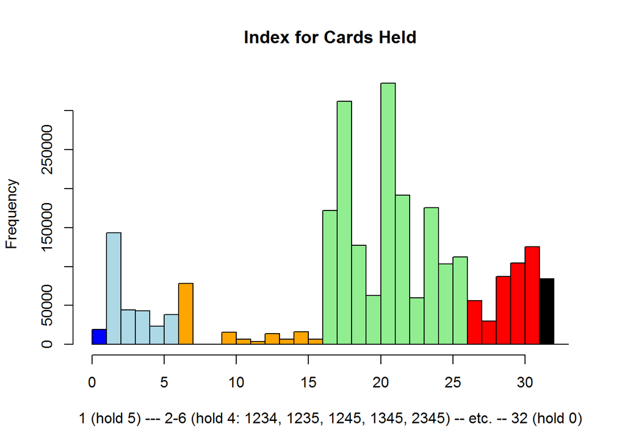

```r
hist(rep(tempSmallMax[2, ], times=cardWeight), breaks=0:33, main="Index for Cards Held",
     xlab="1 (hold 5) --- 2-6 (hold 4: 1234, 1235, 1245, 1345, 2345) -- etc. -- 32 (hold 0)",
     col=c( rep("blue", 1), rep("lightblue", 5), rep("orange", 10),
            rep("lightgreen", 10), rep("red", 5), rep("black", 1)
           )
     )
```

```r
newSmallCutIdx <- cut(tempSmallMax[2, ],
                 breaks=c(0.5, 1.5, 6.5, 16.5, 26.5, 31.5, 32.5)
                 )

data.frame(newType=rep(newSmallCutIdx, times=cardWeight)) %>%
    group_by(newType) %>% summarize(ct=n())
```

```
## Source: local data frame [6 x 2]
##
##       newType      ct
##        (fctr)   (int)
## 1   (0.5,1.5]   19488
## 2   (1.5,6.5]  292176
## 3  (6.5,16.5]  147528
## 4 (16.5,26.5] 1651440
## 5 (26.5,31.5]  403968
## 6 (31.5,32.5]   84360
```

```r
proc.time() - startTime
```

```
##    user  system elapsed
##    0.81    0.07    0.88
```

```r
# Are the summary statistics the same (previously run and checked; big file no longer available)?
# all.equal(1 + mean(rep(tempSmallMax[1, ], times=cardWeight)), 1 + mean(tempMax[1,]))
# all.equal(summary(rep(tempSmallMax[1, ], times=cardWeight)), summary(rep(tempMax[1, ], times=1)))

# Are the holds by number of cards the same (previously run and checked; big file no longer available)?
# all.equal(data.frame(newType=rep(newSmallCutIdx, times=cardWeight)) %>%
#               group_by(newType) %>% summarize(ct=n()),
#           data.frame(newType=rep(newCutIdx, times=1)) %>%
#               group_by(newType) %>% summarize(ct=n())
#           )
```

The control totals and expected values are a good match!

Next is a test to see if pattern recognition can help make the indexing code more compact:

```r
startTime <- proc.time()


# Create a matrix to hold results for choose(n, k)
mtxCombin <- matrix(data=0L, nrow=52, ncol=5)
for (intCtr in 1:52) {
    for (intCtr2 in 1:5) {
        # Note that choose() is a guarded function where choose(n, k) returns 0 for k > n
        mtxCombin[intCtr, intCtr2] <- as.integer(choose(intCtr, intCtr2))
    }
}


idxCardAny <- function(cards) {
    if (length(cards) == 1) {
        cards[1]
    } else if (length(cards) == 2) {
        as.integer(1 + mtxCombin[52, 2] - mtxCombin[53-cards[1], 2] +
                       mtxCombin[52-cards[1], 1] - mtxCombin[53-cards[2], 1]
                   )
    } else if (length(cards) == 3) {
        as.integer(1 + mtxCombin[52, 3] - mtxCombin[53-cards[1], 3] +
                       mtxCombin[52-cards[1], 2] - mtxCombin[53-cards[2], 2] +
                       mtxCombin[52-cards[2], 1] - mtxCombin[53-cards[3], 1]
                   )

    } else if (length(cards) == 4) {
        as.integer(1 + mtxCombin[52, 4] - mtxCombin[53-cards[1], 4] +
                       mtxCombin[52-cards[1], 3] - mtxCombin[53-cards[2], 3] +
                       mtxCombin[52-cards[2], 2] - mtxCombin[53-cards[3], 2] +
                       mtxCombin[52-cards[3], 1] - mtxCombin[53-cards[4], 1]
                   )

    } else if (length(cards) == 5) {
        as.integer(1 + mtxCombin[52, 5] - mtxCombin[53-cards[1], 5] +
                       mtxCombin[52-cards[1], 4] - mtxCombin[53-cards[2], 4] +
                       mtxCombin[52-cards[2], 3] - mtxCombin[53-cards[3], 3] +
                       mtxCombin[52-cards[3], 2] - mtxCombin[53-cards[4], 2] +
                       mtxCombin[52-cards[4], 1] - mtxCombin[53-cards[5], 1]
                   )
    } else {
        stop(paste0("Invalid vector ", cards, " has length: ", length(cards)))
    }
}

# Look at a very small sample of cardSmall
dblCheck <- cardSmall[c(1:10, 1000, 100000), ]

# If you have 3 cards, then you need to find all combinations of 4/5 cards that have those 3 cards
poss5 <- list(c(1, 2, 3, 4, 5))
poss4 <- list(c(1, 2, 3, 4), c(1, 2, 3, 5), c(1, 2, 4, 5), c(1, 3, 4, 5), c(2, 3, 4, 5))
poss3 <- list(c(1, 2, 3), c(1, 2, 4), c(1, 2, 5), c(1, 3, 4), c(1, 3, 5),
              c(1, 4, 5), c(2, 3, 4), c(2, 3, 5), c(2, 4, 5), c(3, 4, 5)
              )
poss2 <- list(c(1, 2), c(1, 3), c(1, 4), c(1, 5), c(2, 3),
              c(2, 4), c(2, 5), c(3, 4), c(3, 5), c(4, 5)
              )
poss1 <- list(c(1), c(2), c(3), c(4), c(5))
poss0 <- list()


# Set up the key arrays
match5to4 <- matrix(data=NA, nrow=5, ncol=1)
match5to3 <- matrix(data=NA, nrow=10, ncol=1)
match5to2 <- matrix(data=NA, nrow=10, ncol=1)
match5to1 <- matrix(data=NA, nrow=5, ncol=1)

match4to3 <- matrix(data=NA, nrow=10, ncol=5)
match4to2 <- matrix(data=NA, nrow=10, ncol=5)
match4to1 <- matrix(data=NA, nrow=5, ncol=5)

match3to2 <- matrix(data=NA, nrow=10, ncol=10)
match3to1 <- matrix(data=NA, nrow=5, ncol=10)

match2to1 <- matrix(data=NA, nrow=5, ncol=10)



# Take each possible poss4 and see which poss5 hands it matches to
for (intCtr in seq_along(poss4)) {
    match5to4[intCtr, ] <- sapply(poss5, FUN=function(x) { sum( poss4[[intCtr]] %in% x ) == 4 } )
}

# Take each possible poss3 and see which poss4 and poss5 hands it matches to
for (intCtr in seq_along(poss3)) {
    match4to3[intCtr, ] <- sapply(poss4, FUN=function(x) { sum( poss3[[intCtr]] %in% x ) == 3 } )
    match5to3[intCtr, ] <- sapply(poss5, FUN=function(x) { sum( poss3[[intCtr]] %in% x ) == 3 } )
}

# Take each possible poss2 and see which poss3 and poss4 and poss5 hands it matches to
for (intCtr in seq_along(poss2)) {
    match3to2[intCtr, ] <- sapply(poss3, FUN=function(x) { sum( poss2[[intCtr]] %in% x ) == 2 } )
    match4to2[intCtr, ] <- sapply(poss4, FUN=function(x) { sum( poss2[[intCtr]] %in% x ) == 2 } )
    match5to2[intCtr, ] <- sapply(poss5, FUN=function(x) { sum( poss2[[intCtr]] %in% x ) == 2 } )
}

# Take each possible poss1 and see which poss2 and poss3 and poss4 and poss5 hands it matches to
for (intCtr in seq_along(poss1)) {
    match2to1[intCtr, ] <- sapply(poss2, FUN=function(x) { sum( poss1[[intCtr]] %in% x ) == 1 } )
    match3to1[intCtr, ] <- sapply(poss3, FUN=function(x) { sum( poss1[[intCtr]] %in% x ) == 1 } )
    match4to1[intCtr, ] <- sapply(poss4, FUN=function(x) { sum( poss1[[intCtr]] %in% x ) == 1 } )
    match5to1[intCtr, ] <- sapply(poss5, FUN=function(x) { sum( poss1[[intCtr]] %in% x ) == 1 } )
}


match5to4
```

```
##      [,1]
## [1,] TRUE
## [2,] TRUE
## [3,] TRUE
## [4,] TRUE
## [5,] TRUE
```

```r
match5to3
```

```
##       [,1]
##  [1,] TRUE
##  [2,] TRUE
##  [3,] TRUE
##  [4,] TRUE
##  [5,] TRUE
##  [6,] TRUE
##  [7,] TRUE
##  [8,] TRUE
##  [9,] TRUE
## [10,] TRUE
```

```r
match5to2
```

```
##       [,1]
##  [1,] TRUE
##  [2,] TRUE
##  [3,] TRUE
##  [4,] TRUE
##  [5,] TRUE
##  [6,] TRUE
##  [7,] TRUE
##  [8,] TRUE
##  [9,] TRUE
## [10,] TRUE
```

```r
match5to1
```

```
##      [,1]
## [1,] TRUE
## [2,] TRUE
## [3,] TRUE
## [4,] TRUE
## [5,] TRUE
```

```r
match4to3
```

```
##        [,1]  [,2]  [,3]  [,4]  [,5]
##  [1,]  TRUE  TRUE FALSE FALSE FALSE
##  [2,]  TRUE FALSE  TRUE FALSE FALSE
##  [3,] FALSE  TRUE  TRUE FALSE FALSE
##  [4,]  TRUE FALSE FALSE  TRUE FALSE
##  [5,] FALSE  TRUE FALSE  TRUE FALSE
##  [6,] FALSE FALSE  TRUE  TRUE FALSE
##  [7,]  TRUE FALSE FALSE FALSE  TRUE
##  [8,] FALSE  TRUE FALSE FALSE  TRUE
##  [9,] FALSE FALSE  TRUE FALSE  TRUE
## [10,] FALSE FALSE FALSE  TRUE  TRUE
```

```r
match4to2
```

```
##        [,1]  [,2]  [,3]  [,4]  [,5]
##  [1,]  TRUE  TRUE  TRUE FALSE FALSE
##  [2,]  TRUE  TRUE FALSE  TRUE FALSE
##  [3,]  TRUE FALSE  TRUE  TRUE FALSE
##  [4,] FALSE  TRUE  TRUE  TRUE FALSE
##  [5,]  TRUE  TRUE FALSE FALSE  TRUE
##  [6,]  TRUE FALSE  TRUE FALSE  TRUE
##  [7,] FALSE  TRUE  TRUE FALSE  TRUE
##  [8,]  TRUE FALSE FALSE  TRUE  TRUE
##  [9,] FALSE  TRUE FALSE  TRUE  TRUE
## [10,] FALSE FALSE  TRUE  TRUE  TRUE
```

```r
match4to1
```

```
##       [,1]  [,2]  [,3]  [,4]  [,5]
## [1,]  TRUE  TRUE  TRUE  TRUE FALSE
## [2,]  TRUE  TRUE  TRUE FALSE  TRUE
## [3,]  TRUE  TRUE FALSE  TRUE  TRUE
## [4,]  TRUE FALSE  TRUE  TRUE  TRUE
## [5,] FALSE  TRUE  TRUE  TRUE  TRUE
```

```r
match3to2
```

```
##        [,1]  [,2]  [,3]  [,4]  [,5]  [,6]  [,7]  [,8]  [,9] [,10]
##  [1,]  TRUE  TRUE  TRUE FALSE FALSE FALSE FALSE FALSE FALSE FALSE
##  [2,]  TRUE FALSE FALSE  TRUE  TRUE FALSE FALSE FALSE FALSE FALSE
##  [3,] FALSE  TRUE FALSE  TRUE FALSE  TRUE FALSE FALSE FALSE FALSE
##  [4,] FALSE FALSE  TRUE FALSE  TRUE  TRUE FALSE FALSE FALSE FALSE
##  [5,]  TRUE FALSE FALSE FALSE FALSE FALSE  TRUE  TRUE FALSE FALSE
##  [6,] FALSE  TRUE FALSE FALSE FALSE FALSE  TRUE FALSE  TRUE FALSE
##  [7,] FALSE FALSE  TRUE FALSE FALSE FALSE FALSE  TRUE  TRUE FALSE
##  [8,] FALSE FALSE FALSE  TRUE FALSE FALSE  TRUE FALSE FALSE  TRUE
##  [9,] FALSE FALSE FALSE FALSE  TRUE FALSE FALSE  TRUE FALSE  TRUE
## [10,] FALSE FALSE FALSE FALSE FALSE  TRUE FALSE FALSE  TRUE  TRUE
```

```r
match3to1
```

```
##       [,1]  [,2]  [,3]  [,4]  [,5]  [,6]  [,7]  [,8]  [,9] [,10]
## [1,]  TRUE  TRUE  TRUE  TRUE  TRUE  TRUE FALSE FALSE FALSE FALSE
## [2,]  TRUE  TRUE  TRUE FALSE FALSE FALSE  TRUE  TRUE  TRUE FALSE
## [3,]  TRUE FALSE FALSE  TRUE  TRUE FALSE  TRUE  TRUE FALSE  TRUE
## [4,] FALSE  TRUE FALSE  TRUE FALSE  TRUE  TRUE FALSE  TRUE  TRUE
## [5,] FALSE FALSE  TRUE FALSE  TRUE  TRUE FALSE  TRUE  TRUE  TRUE
```

```r
match2to1
```

```
##       [,1]  [,2]  [,3]  [,4]  [,5]  [,6]  [,7]  [,8]  [,9] [,10]
## [1,]  TRUE  TRUE  TRUE  TRUE FALSE FALSE FALSE FALSE FALSE FALSE
## [2,]  TRUE FALSE FALSE FALSE  TRUE  TRUE  TRUE FALSE FALSE FALSE
## [3,] FALSE  TRUE FALSE FALSE  TRUE FALSE FALSE  TRUE  TRUE FALSE
## [4,] FALSE FALSE  TRUE FALSE FALSE  TRUE FALSE  TRUE FALSE  TRUE
## [5,] FALSE FALSE FALSE  TRUE FALSE FALSE  TRUE FALSE  TRUE  TRUE
```

```r
proc.time() - startTime
```

```
##    user  system elapsed
##    0.05    0.00    0.05
```